# Background Information:

In a Stroop task, participants are presented with a list of words, with each word displayed in a color of ink. The participant’s task is to say out loud the color of the ink in which the word is printed. The task has two conditions: a congruent words condition, and an incongruent words condition. In the congruent words condition, the words being displayed are color words whose names match the colors in which they are printed: for example RED, BLUE. In the incongruent words condition, the words displayed are color words whose names do not match the colors in which they are printed: for example PURPLE, ORANGE. In each case, we measure the time it takes to name the ink colors in equally-sized lists. Each participant will go through and record a time from each condition.

The below images gives a clear idea about the project.

Below is the image that how the Incongruent words look like

[figure not shown]

Below is the image that how the Incongruent words look like

[figure not shown]

# Questions For Investigation

1.What is our independent variable? What is our dependent variable?

-> Independent variable: Task given to the student to identify that it is congruent condition or the incongruent condition.

-> Dependent variable: The time taken to identify finish naming the ink colors in a list of words.

2.What is an appropriate set of hypotheses for this task? What kind of statistical test do you expect to perform? Justify your choices.

Based on my past test experience i decided that

Null hypothesis (H-Null): A null hypothesis is that there is no change or decrease in the time for the given task. [H-Null: μi ≤ μc]

Alternate hypothesis (H-Alt): A alternate hypothesis is that their is increase in the time for task. [H-Alt: μi > μc]

μi -> Mean of incongruent values

μc -> Mean of congrient values

H-Null -> Null Hypothesis

H-Alt -> Alternate Hypothesis

Here we are considering that incogruent-task takes more time because when we take the sample means of both congruent and incongruent tasks, we see that average incongruent task takes more time than congruent. So we consider H-alt. But our assumption goes wrong when we conider a group of talented people.

Here in this task the statistical test i would like to perform is dependent one tail t-test. The dependent sample t-test is useful because the same group of people are tested 2 times for diffrent tasks which let us know whether to accept or reject the null hypothesis.

Reasons for t-test:

We dont know the population standard deviations and the sample size which was given is 24 more over every one had taken the test at different times. By which we can just compare the two averages of the dependent samples with the help of one-tailed test.

3.Report some descriptive statistics regarding this dataset. Include at least one measure of central tendency and at least one measure of variability.

```python
# Imports for python
import math
import pandas as pd
import numpy as np
import seaborn as sns
from scipy.stats import t
%matplotlib inline
```

```python
df = pd.read_csv('./stroopdata.csv') #Loading of data.
```

```python
print(df)
```

```
    Congruent  Incongruent
0      12.079       19.278
1      16.791       18.741
2       9.564       21.214
3       8.630       15.687
4      14.669       22.803
5      12.238       20.878
6      14.692       24.572
7       8.987       17.394
8       9.401       20.762
9      14.480       26.282
10     22.328       24.524
11     15.298       18.644
12     15.073       17.510
13     16.929       20.330
14     18.200       35.255
15     12.130       22.158
16     18.495       25.139
17     10.639       20.429
18     11.344       17.425
19     12.369       34.288
20     12.944       23.894
21     14.233       17.960
22     19.710       22.058
23     16.004       21.157
```

```python
congruentSeries = df['Congruent']
incongruentSeries = df['Incongruent']
```

```python
# Create a Series and DataFrame for the difference between the two conditions
differenceSeries = incongruentSeries - congruentSeries
differenceDataFrame = pd.DataFrame({"Difference":differenceSeries})
```

```python
df.describe()
```

[output not shown]

```python
#mean: $xbar = \Sigma{x}/n$ (where xbar is the sample mean, x is the value and n is the number of samples)
print(df.mean(axis=0))
```

```
Congruent      14.051125
Incongruent    22.015917
dtype: float64
```

```python
#sample std. deviation: $\sigma = \Sigma{(x - xbar)^2}/n$
print(df.std(axis=0))
```

```
Congruent      3.559358
Incongruent    4.797057
dtype: float64
```

4.Provide one or two visualizations that show the distribution of the sample data. Write one or two sentences noting what you observe about the plot or plots.

```python
import matplotlib.pyplot as plt
plt.style.use('ggplot')
```

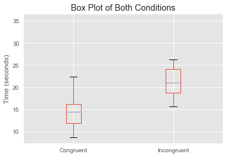

```python
# Box plots of the two conditions
title = 'Box Plot of Both Conditions'
kind = 'box'
df.plot(title=title, kind=kind)
ylabel = plt.ylabel('Time (seconds)')
```

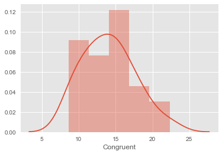

```python
sns.distplot(df['Congruent'])
```

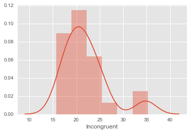

```python
sns.distplot(df['Incongruent'])
```

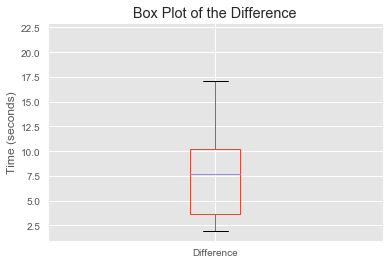

```python
# Box plots of the difference between the two conditions
title = 'Box Plot of the Difference'
kind = 'box'
differenceDataFrame.plot(title=title, kind=kind)
ylabel = plt.ylabel('Time (seconds)')
```

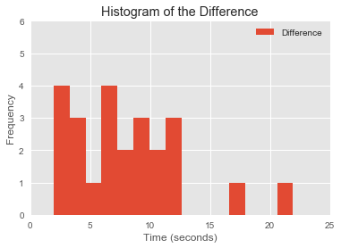

```python
# Histogram of the Difference between the Two Conditions
title = 'Histogram of the Difference'
kind = 'hist'
plot = differenceDataFrame.plot(title=title, kind=kind, bins=15)
xLabel = plt.xlabel('Time (seconds)')
window = plt.axis([0,25,0,6])
```

The complete visualization of congruent and incongruent can be viewed in the above three figures. The mean, median and standard deviation can be observed in those three figures.

From the last two figures the difference between the congruent and incongruent statistics can be observed.

Mean difference -> 7.964792

Median difference -> 7.6665

std -> 4.864827

5 Now, perform the statistical test and report your results. What is your confidence level and your critical statistic value? Do you reject the null hypothesis or fail to reject it? Come to a conclusion in terms of the experiment task. Did the results match up with your expectations?

```python
# Make sure that our samples are of the same size, and show that size
print(df['Congruent'].size)
print(df['Incongruent'].size)
```

```
24
24
```

```python
# Get the t-critical value for a 95% confidence level and 23 d.f (i.e 24 is the count and degree of freedom = count-1)
t.ppf(.95, 23)
```

```
1.7138715277470473
```

```python
df['Difference'] = df['Congruent'] - df['Incongruent']
df['Difference'].std(axis=0)
```

```
4.864826910359056
```

```python
7.97/(4.8648 / math.sqrt(24))
```

```
8.025996238275749
```

t-distribution with n-1 degrees of freedom (df = 23). Using the t-distribution table to find p-value...

The value of p is < 0.0001. The result is significant at p < 0.05%

So as we see that t-statistic value is 8.02 which is greater than our critical value which is of 1.7139. So we reject the null hypothesis. Which states that it takes much less time to do congruent task than to do incongruent task, which matched our intution.